# Diffusion map of Ising model

## Critical temperature

```python
import numpy as np
import matplotlib.pyplot as plt
from sklearn.metrics import pairwise_distances
from scipy.linalg import eigh

def initialize_spin_grid(size):
    return np.random.choice([-1, 1], size=(size, size))

def calculate_energy(spin_grid):
    energy = 0
    for i in range(len(spin_grid)):
        for j in range(len(spin_grid)):
            spin = spin_grid[i, j]
            neighbors_sum = spin_grid[(i+1)%size, j] + spin_grid[i, (j+1)%size] + spin_grid[(i-1)%size, j] + spin_grid[i, (j-1)%size]
            energy += -spin * neighbors_sum
    return energy / 2

def metropolis(spin_grid, temperature):
    i, j = np.random.randint(0, size, 2)
    spin = spin_grid[i, j]
    neighbors_sum = spin_grid[(i+1)%size, j] + spin_grid[i, (j+1)%size] + spin_grid[(i-1)%size, j] + spin_grid[i, (j-1)%size]
    energy_diff = 2 * spin * neighbors_sum
    if energy_diff < 0 or np.random.rand() < np.exp(-energy_diff / temperature):
        spin_grid[i, j] = -spin
    return spin_grid

def simulate_ising_model(size, temperature, steps):
    spin_grid = initialize_spin_grid(size)
    energies = []
    spin_configs = []
    for _ in range(steps):
        spin_grid = metropolis(spin_grid, temperature)
        energy = calculate_energy(spin_grid)
        energies.append(energy)
        spin_configs.append(spin_grid.copy().reshape(-1))  # Store flattened spin configuration
    return spin_configs, energies

def diffusion_map(data, epsilon=1.0, n_components=2):
    # Compute the pairwise squared Euclidean distances
    dists = pairwise_distances(data, metric='sqeuclidean')

    # Compute the similarity matrix using a Gaussian kernel
    W = np.exp(-dists / (4 * epsilon))

    # Normalize the rows of W to sum to 1 (Markov matrix)
    D = np.sum(W, axis=1)
    P = W / D[:, None]

    # Compute the eigenvalues and eigenvectors of P
    eigenvalues, eigenvectors = eigh(P)

    # Sort eigenvectors by eigenvalue in descending order
    sorted_indices = np.argsort(eigenvalues)[::-1]
    eigenvectors = eigenvectors[:, sorted_indices]

    # Select the top n_components eigenvectors (excluding the first one)
    diffusion_coordinates = eigenvectors[:, 1:n_components+1]

    return diffusion_coordinates
```

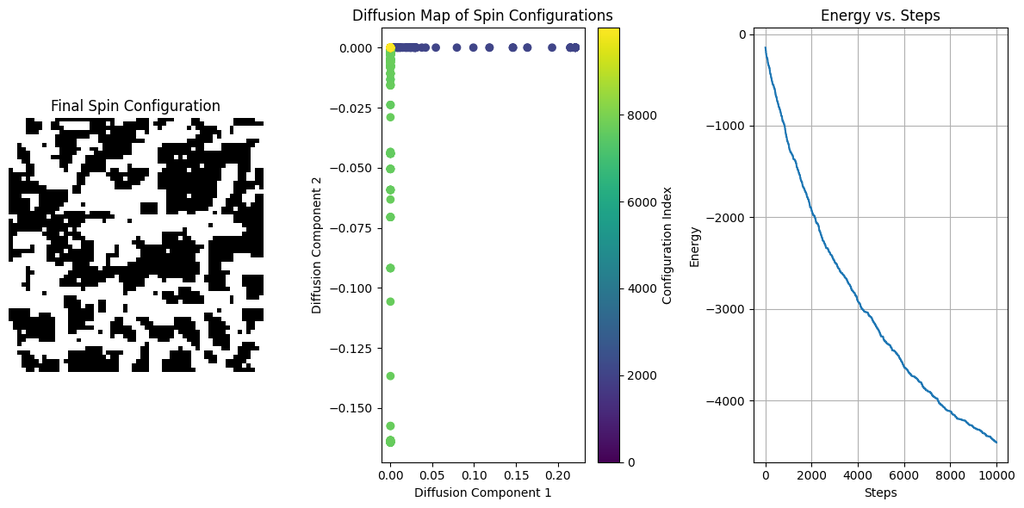

```python
# Parameters
size = 60
temperature = 0.5
steps = 10000

# Simulation
spin_configs, energies = simulate_ising_model(size, temperature, steps)

# Compute the diffusion map
diffusion_coords = diffusion_map(np.array(spin_configs))

# Plotting the results
plt.figure(figsize=(12, 6))

# Plot the final spin configuration
plt.subplot(1, 3, 1)
plt.imshow(spin_configs[-1].reshape(size, size), cmap='binary', interpolation='nearest')
plt.title('Final Spin Configuration')
plt.axis('off')

# Plot the diffusion map
plt.subplot(1, 3, 2)
plt.scatter(diffusion_coords[:, 0], diffusion_coords[:, 1], c=np.arange(len(spin_configs)), cmap='viridis')
plt.colorbar(label='Configuration Index')
plt.title('Diffusion Map of Spin Configurations')
plt.xlabel('Diffusion Component 1')
plt.ylabel('Diffusion Component 2')

# Plot the energy of the states at each step
plt.subplot(1, 3, 3)
plt.plot(energies)
plt.title('Energy vs. Steps')
plt.xlabel('Steps')
plt.ylabel('Energy')
plt.grid(True)

plt.tight_layout()
plt.show()
```

## Plot the progression of states

```
(-0.5, 59.5, 59.5, -0.5)
```

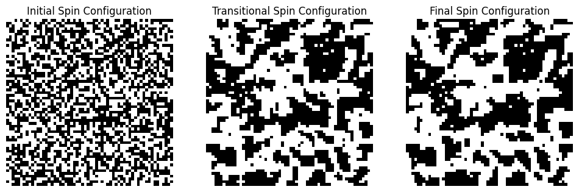

```python
# Plotting the results
plt.figure(figsize=(12, 6))

# Plot the initial spin configuration
plt.subplot(1, 3, 1)
plt.imshow(spin_configs[0].reshape(size, size), cmap='binary', interpolation='nearest')
plt.title('Initial Spin Configuration')
plt.axis('off')

# Plot the transitional spin configuration
plt.subplot(1, 3, 2)
plt.imshow(spin_configs[8000].reshape(size, size), cmap='binary', interpolation='nearest')
plt.title('Transitional Spin Configuration')
plt.axis('off')

# Plot the final spin configuration
plt.subplot(1, 3, 3)
plt.imshow(spin_configs[-1].reshape(size, size), cmap='binary', interpolation='nearest')
plt.title('Final Spin Configuration')
plt.axis('off')
```

## Initial states in high energy configuration

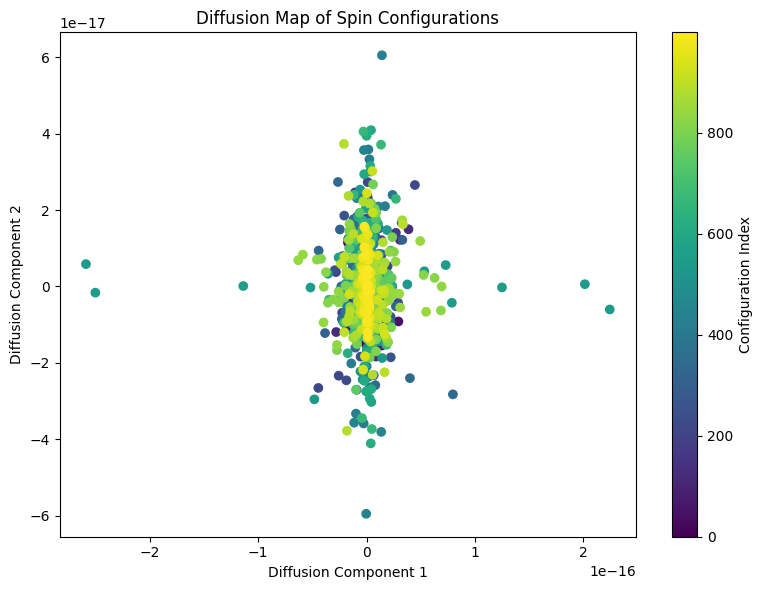

```python
# Plot the diffusion map
plt.figure(figsize=(8, 6))
plt.scatter(diffusion_coords[:1000, 0], diffusion_coords[:1000, 1], c=np.arange(1000), cmap='viridis')
plt.colorbar(label='Configuration Index')
plt.title('Diffusion Map of Spin Configurations')
plt.xlabel('Diffusion Component 1')
plt.ylabel('Diffusion Component 2')

plt.tight_layout()
plt.show()
```

We can see the results here are difficult to separate.

## Final states

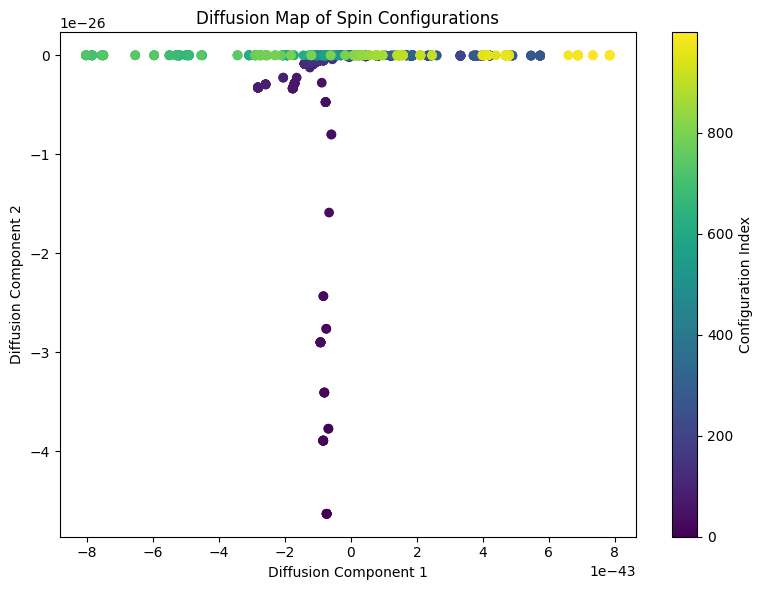

```python
# Plot the diffusion map
plt.figure(figsize=(8, 6))
plt.scatter(diffusion_coords[-1000:, 0], diffusion_coords[-1000:, 1], c=np.arange(1000), cmap='viridis')
plt.colorbar(label='Configuration Index')
plt.title('Diffusion Map of Spin Configurations')
plt.xlabel('Diffusion Component 1')
plt.ylabel('Diffusion Component 2')

plt.tight_layout()
plt.show()
```

We can see the map here was especially ineffective at separating the states.

## Near-critical energy

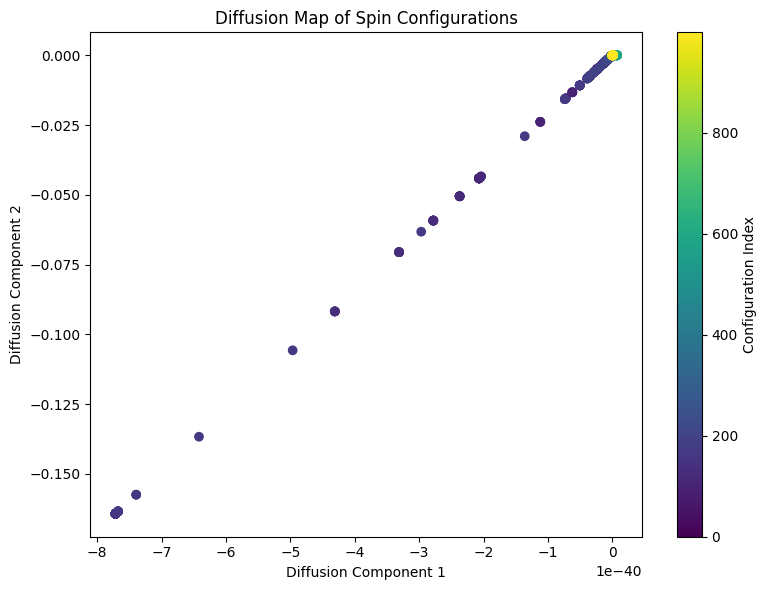

```python
# Plot the diffusion map
plt.figure(figsize=(8, 6))
plt.scatter(diffusion_coords[7500:8500, 0], diffusion_coords[7500:8500, 1], c=np.arange(1000), cmap='viridis')
plt.colorbar(label='Configuration Index')
plt.title('Diffusion Map of Spin Configurations')
plt.xlabel('Diffusion Component 1')
plt.ylabel('Diffusion Component 2')

plt.tight_layout()
plt.show()
```

Here, we can see the separation is once again poor.

## More general distribution of drift

```python
import numpy as np
from scipy.spatial.distance import pdist, squareform
from scipy.sparse import diags
from scipy.sparse.linalg import eigs
import matplotlib.pyplot as plt

def TMDmap(data, target_distribution, epsilon=1.0, beta=1.0, n_components=10):
    """
    Generalized diffusion map with target distribution.

    Parameters:
    - data: (N x dim) array of N data points of dimension dim.
    - target_distribution: (N x 1) array representing the target distribution.
    - epsilon: Scaling parameter for the kernel (default 1.0).
    - beta: Inverse temperature (default 1.0).
    - n_components: Number of diffusion map components to compute (default 10).

    Returns:
    - eval: The top n_components eigenvalues.
    - evec: The top n_components eigenvectors.
    """
    # Number of data points
    m = data.shape[0]

    # Compute the pairwise squared Euclidean distances
    dists = squareform(pdist(data, metric='sqeuclidean'))

    # Compute the Gaussian kernel matrix
    A = np.exp(-dists / (4 * epsilon))

    # Compute weights from the target distribution
    weights = np.sqrt(target_distribution)

    # Normalize the kernel matrix
    q = np.sum(A, axis=1)
    D = diags(weights * q)

    # Apply the normalization to get matrix K
    K = A @ D

    # Further normalization
    row_sums = np.sum(K, axis=1)
    K = np.diag(1.0 / row_sums) @ K

    # Compute the local generator L_loc
    L_loc = 4 / (beta * epsilon) * (K - np.diag(row_sums))

    # Compute eigenvalues and eigenvectors
    eval, evec = eigs(L_loc, k=n_components, which='LR')

    # Sort eigenvalues and eigenvectors by eigenvalue magnitude
    eval = np.real(eval)
    indices = np.argsort(eval)[::-1]
    eval = eval[indices]
    evec = evec[:, indices]

    return eval, np.real(evec)
```

```python
# Example target distribution (e.g., based on a potential energy function)
beta = 8.0
target_distribution = np.exp(-beta * np.sum(diffusion_coords**2, axis=1))  # Simple quadratic potential

# Perform diffusion map
eval, evec = TMDmap(diffusion_coords, target_distribution, epsilon=1.0, beta=beta, n_components=10)
```

## Map of full data

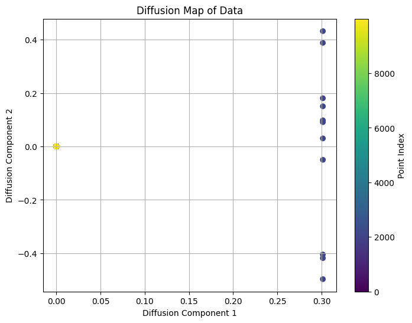

```
Top 3 Eigenvalues: [-49351674.57077985 -49351674.57123246 -49351674.57123252]
Corresponding Eigenvectors (first 3 rows):
 [[ 2.20536209e-10 -7.38384184e-16  2.82141874e-15]
 [ 2.20536209e-10 -6.15574692e-16  2.57235096e-15]
 [ 2.20536220e-10 -6.63362429e-16  2.75703589e-15]]
```

```python
# Plot the first two diffusion map components
plt.figure(figsize=(8, 6))
plt.scatter(evec[:, 0], evec[:, 1], c=np.arange(steps), cmap='viridis')
plt.colorbar(label='Point Index')
plt.title('Diffusion Map of Data')
plt.xlabel('Diffusion Component 1')
plt.ylabel('Diffusion Component 2')
plt.grid(True)
plt.show()

# Print the top 3 eigenvalues and their corresponding eigenvectors
print("Top 3 Eigenvalues:", eval[:3])
print("Corresponding Eigenvectors (first 3 rows):\n", evec[:3, :3])
```

Here, we can see the map across the entire dataset struggles to separate the data across the radically different conditions through which the system passes. Let's examine specific periods in turn to see how the performance compares.

## Initial states

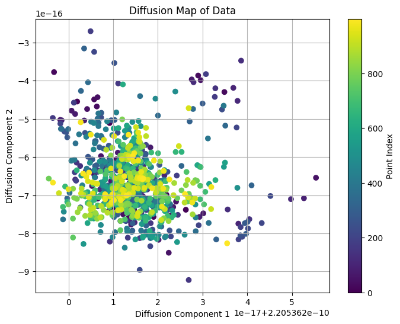

```
Top 3 Eigenvalues: [-49351674.57077985 -49351674.57123246 -49351674.57123252]
Corresponding Eigenvectors (first 3 rows):
 [[ 2.20536209e-10 -7.38384184e-16  2.82141874e-15]
 [ 2.20536209e-10 -6.15574692e-16  2.57235096e-15]
 [ 2.20536220e-10 -6.63362429e-16  2.75703589e-15]]
```

```python
# Plot the first two diffusion map components
plt.figure(figsize=(8, 6))
plt.scatter(evec[:1000, 0], evec[:1000, 1], c=np.arange(1000), cmap='viridis')
plt.colorbar(label='Point Index')
plt.title('Diffusion Map of Data')
plt.xlabel('Diffusion Component 1')
plt.ylabel('Diffusion Component 2')
plt.grid(True)
plt.show()

# Print the top 3 eigenvalues and their corresponding eigenvectors
print("Top 3 Eigenvalues:", eval[:3])
print("Corresponding Eigenvectors (first 3 rows):\n", evec[:3, :3])
```

Here, we can see the map generated is able to at least weakly separate the initial states based on their spread, with earlier data points mapped to more variable points in the compressed manifold. This is consistent with expectation given the initial state was a high-energy random state which is cooling in this period to a lower energy state.

## Final states

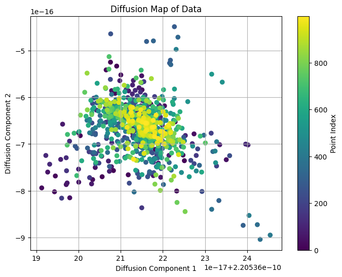

```
Top 3 Eigenvalues: [-49351674.57077985 -49351674.57123246 -49351674.57123252]
Corresponding Eigenvectors (first 3 rows):
 [[ 2.20536209e-10 -7.38384184e-16  2.82141874e-15]
 [ 2.20536209e-10 -6.15574692e-16  2.57235096e-15]
 [ 2.20536220e-10 -6.63362429e-16  2.75703589e-15]]
```

```python
# Plot the first two diffusion map components
plt.figure(figsize=(8, 6))
plt.scatter(evec[-1000:, 0], evec[-1000:, 1], c=np.arange(1000), cmap='viridis')
plt.colorbar(label='Point Index')
plt.title('Diffusion Map of Data')
plt.xlabel('Diffusion Component 1')
plt.ylabel('Diffusion Component 2')
plt.grid(True)
plt.show()

# Print the top 3 eigenvalues and their corresponding eigenvectors
print("Top 3 Eigenvalues:", eval[:3])
print("Corresponding Eigenvectors (first 3 rows):\n", evec[:3, :3])
```

## Near-critical energy

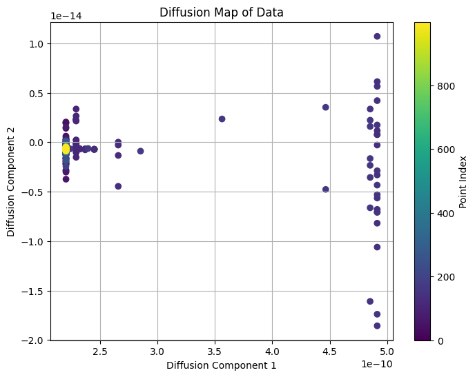

```
Top 3 Eigenvalues: [-49351674.57077985 -49351674.57123246 -49351674.57123252]
Corresponding Eigenvectors (first 3 rows):
 [[ 2.20536209e-10 -7.38384184e-16  2.82141874e-15]
 [ 2.20536209e-10 -6.15574692e-16  2.57235096e-15]
 [ 2.20536220e-10 -6.63362429e-16  2.75703589e-15]]
```

```python
# Plot the first two diffusion map components
plt.figure(figsize=(8, 6))
plt.scatter(evec[7500:8500, 0], evec[7500:8500, 1], c=np.arange(1000), cmap='viridis')
plt.colorbar(label='Point Index')
plt.title('Diffusion Map of Data')
plt.xlabel('Diffusion Component 1')
plt.ylabel('Diffusion Component 2')
plt.grid(True)
plt.show()

# Print the top 3 eigenvalues and their corresponding eigenvectors
print("Top 3 Eigenvalues:", eval[:3])
print("Corresponding Eigenvectors (first 3 rows):\n", evec[:3, :3])
```

# High-temperature map

Here, we would not expect a meaningful compression to be practical, as the high temperature keeps the state near maximal entropy

```python
import numpy as np
import matplotlib.pyplot as plt
from sklearn.metrics import pairwise_distances
from scipy.linalg import eigh

# Parameters
size = 60
temperature = 8.0
steps = 10000

# Simulation
spin_configs, energies = simulate_ising_model(size, temperature, steps)

# Compute the diffusion map
diffusion_coords = diffusion_map(np.array(spin_configs))

# Example target distribution (e.g., based on a potential energy function)
beta = 8.0
target_distribution = np.exp(-beta * np.sum(diffusion_coords**2, axis=1))  # Simple quadratic potential

# Perform diffusion map
eval, evec = TMDmap(diffusion_coords, target_distribution, epsilon=1.0, beta=beta, n_components=10)
```

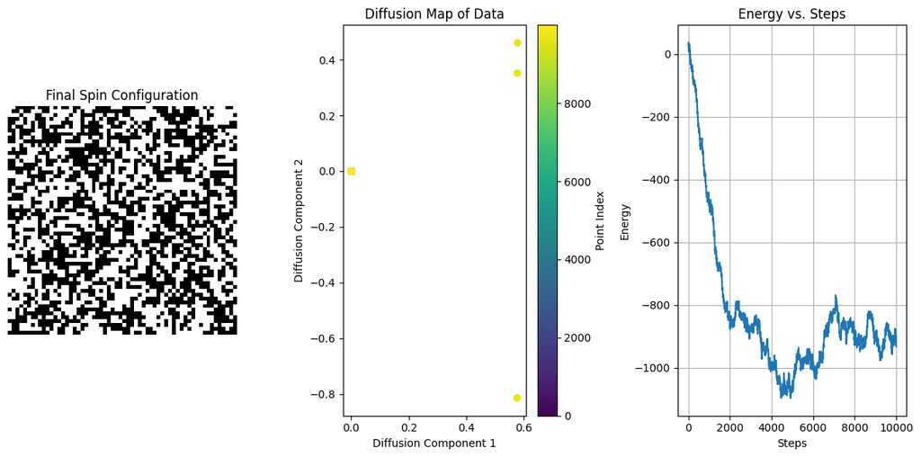

```python
# Plotting the results
plt.figure(figsize=(12, 6))

# Plot the final spin configuration
plt.subplot(1, 3, 1)
plt.imshow(spin_configs[-1].reshape(size, size), cmap='binary', interpolation='nearest')
plt.title('Final Spin Configuration')
plt.axis('off')

# Plot the diffusion map
plt.subplot(1, 3, 2)
plt.scatter(evec[:, 0], evec[:, 1], c=np.arange(steps), cmap='viridis')
plt.colorbar(label='Point Index')
plt.title('Diffusion Map of Data')
plt.xlabel('Diffusion Component 1')
plt.ylabel('Diffusion Component 2')

# Plot the energy of the states at each step
plt.subplot(1, 3, 3)
plt.plot(energies)
plt.title('Energy vs. Steps')
plt.xlabel('Steps')
plt.ylabel('Energy')
plt.grid(True)

plt.tight_layout()
plt.show()
```

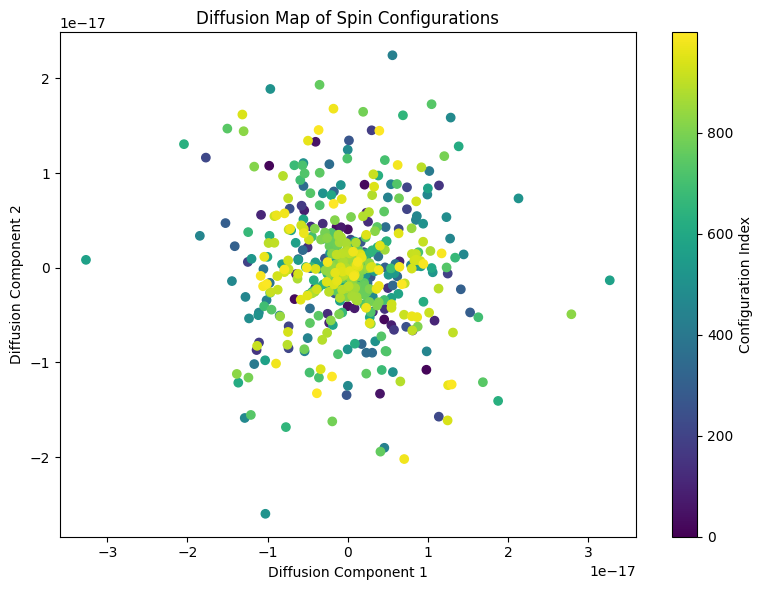

```python
# Plot the diffusion map
plt.figure(figsize=(8, 6))
plt.scatter(diffusion_coords[:1000, 0], diffusion_coords[:1000, 1], c=np.arange(1000), cmap='viridis')
plt.colorbar(label='Configuration Index')
plt.title('Diffusion Map of Spin Configurations')
plt.xlabel('Diffusion Component 1')
plt.ylabel('Diffusion Component 2')

plt.tight_layout()
plt.show()
```

There may be a slight decrease in the variance for later time steps due to the steep initial drop in energy, but this should not be expected to continue

# Final states

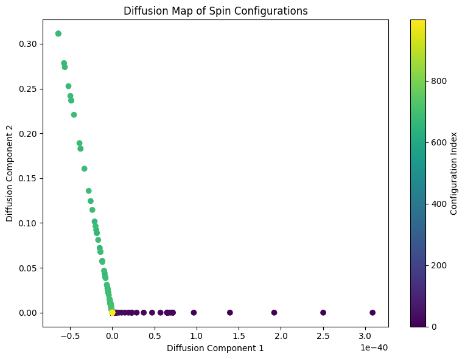

```python
# Plot the diffusion map
plt.figure(figsize=(8, 6))
plt.scatter(diffusion_coords[-1000:, 0], diffusion_coords[-1000:, 1], c=np.arange(1000), cmap='viridis')
plt.colorbar(label='Configuration Index')
plt.title('Diffusion Map of Spin Configurations')
plt.xlabel('Diffusion Component 1')
plt.ylabel('Diffusion Component 2')

plt.tight_layout()
plt.show()
```

# Intermediate steps

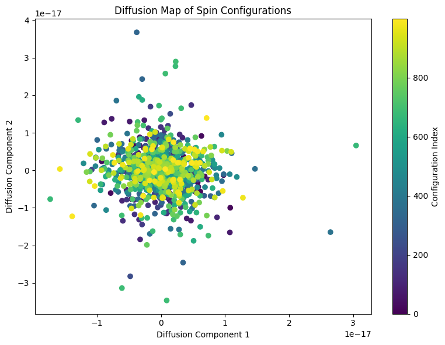

```python
# Plot the diffusion map
plt.figure(figsize=(8, 6))
plt.scatter(diffusion_coords[4500:5500, 0], diffusion_coords[4500:5500, 1], c=np.arange(1000), cmap='viridis')
plt.colorbar(label='Configuration Index')
plt.title('Diffusion Map of Spin Configurations')
plt.xlabel('Diffusion Component 1')
plt.ylabel('Diffusion Component 2')

plt.tight_layout()
plt.show()
```

# Random Graph

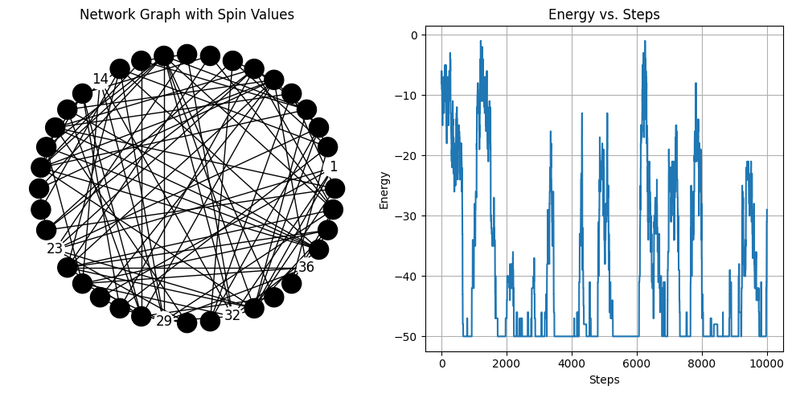

```python
import numpy as np
import matplotlib.pyplot as plt
import networkx as nx

def initialize_spin_graph(graph):
    for node in graph.nodes():
        graph.nodes[node]['spin'] = np.random.choice([-1, 1])

def calculate_energy(graph):
    energy = 0
    for edge in graph.edges():
        i, j = edge
        energy += -graph.nodes[i]['spin'] * graph.nodes[j]['spin']
    return energy / 2

def metropolis(graph, temperature):
    node = np.random.choice(list(graph.nodes()))
    spin = graph.nodes[node]['spin']
    neighbors = list(graph.neighbors(node))
    neighbor = np.random.choice(neighbors)
    energy_diff = 2 * spin * graph.nodes[neighbor]['spin']
    if energy_diff < 0 or np.random.rand() < np.exp(-energy_diff / temperature):
        graph.nodes[node]['spin'] = -spin

def simulate_ising_model(graph, temperature, steps):
    energies = []
    spin_configs = []
    for _ in range(steps):
        metropolis(graph, temperature)
        energy = calculate_energy(graph)
        energies.append(energy)

        # Store the current spin configuration
        current_spin_config = [graph.nodes[node]['spin'] for node in graph.nodes()]
        spin_configs.append(current_spin_config)

    return spin_configs, energies


# Parameters
num_nodes = 40
num_edges = 100
temperature = 0.4
steps = 10000

# Create a random graph
graph = nx.gnm_random_graph(num_nodes, num_edges)

# Initialize spins
initialize_spin_graph(graph)

# Simulation
spin_configs, energies = simulate_ising_model(graph, temperature, steps)

# Plotting
plt.figure(figsize=(10, 5))

# Plot the network graph
plt.subplot(1, 2, 1)
pos = nx.circular_layout(graph)
nx.draw(graph, pos, with_labels=True, node_color=[graph.nodes[node]['spin'] for node in graph.nodes()], cmap=plt.cm.binary)
plt.title('Network Graph with Spin Values')

# Plot the energy evolution
plt.subplot(1, 2, 2)
plt.plot(energies)
plt.title('Energy vs. Steps')
plt.xlabel('Steps')
plt.ylabel('Energy')
plt.grid(True)

plt.tight_layout()
plt.show()
```

```python
# Compute the diffusion map
diffusion_coords = diffusion_map(np.array(spin_configs))

# Example target distribution (e.g., based on a potential energy function)
beta = 8.0
target_distribution = np.exp(-beta * np.sum(diffusion_coords**2, axis=1))  # Simple quadratic potential

# Perform diffusion map
eval, evec = TMDmap(diffusion_coords, target_distribution, epsilon=1.0, beta=beta, n_components=10)
```

## Full map

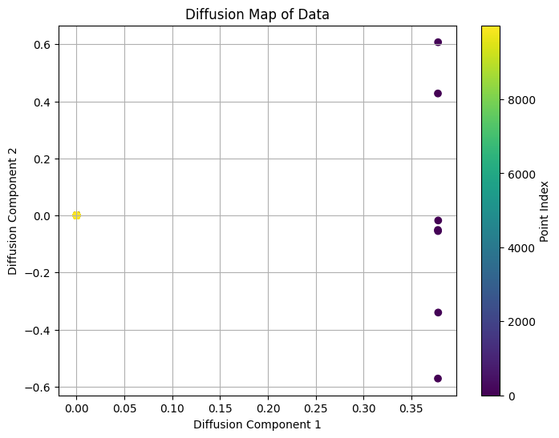

```
Top 3 Eigenvalues: [-49372336.3617586  -49372336.36204842 -49372336.36204842]
Corresponding Eigenvectors (first 3 rows):
 [[ 1.98593622e-10  7.12085058e-15 -8.23347903e-14]
 [ 1.98597404e-10  6.91229401e-15 -8.09087717e-14]
 [ 1.98591986e-10  9.00431546e-15 -9.27664188e-14]]
```

```python
# Plot the first two diffusion map components
plt.figure(figsize=(8, 6))
plt.scatter(evec[:, 0], evec[:, 1], c=np.arange(steps), cmap='viridis')
plt.colorbar(label='Point Index')
plt.title('Diffusion Map of Data')
plt.xlabel('Diffusion Component 1')
plt.ylabel('Diffusion Component 2')
plt.grid(True)
plt.show()

# Print the top 3 eigenvalues and their corresponding eigenvectors
print("Top 3 Eigenvalues:", eval[:3])
print("Corresponding Eigenvectors (first 3 rows):\n", evec[:3, :3])
```

## Final states

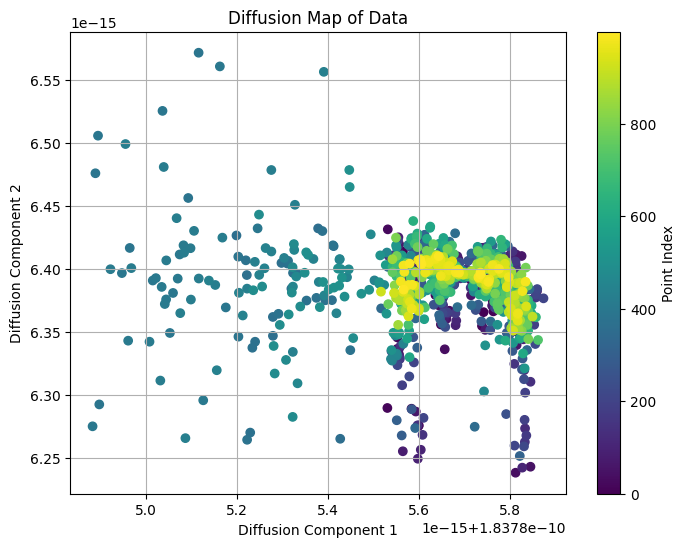

```
Top 3 Eigenvalues: [-49372336.3617586  -49372336.36204842 -49372336.36204842]
Corresponding Eigenvectors (first 3 rows):
 [[ 1.98593622e-10  7.12085058e-15 -8.23347903e-14]
 [ 1.98597404e-10  6.91229401e-15 -8.09087717e-14]
 [ 1.98591986e-10  9.00431546e-15 -9.27664188e-14]]
```

```python
# Plot the first two diffusion map components
plt.figure(figsize=(8, 6))
plt.scatter(evec[-1000:, 0], evec[-1000:, 1], c=np.arange(1000), cmap='viridis')
plt.colorbar(label='Point Index')
plt.title('Diffusion Map of Data')
plt.xlabel('Diffusion Component 1')
plt.ylabel('Diffusion Component 2')
plt.grid(True)
plt.show()

# Print the top 3 eigenvalues and their corresponding eigenvectors
print("Top 3 Eigenvalues:", eval[:3])
print("Corresponding Eigenvectors (first 3 rows):\n", evec[:3, :3])
```

# Structured Graphs

## Fully Connected

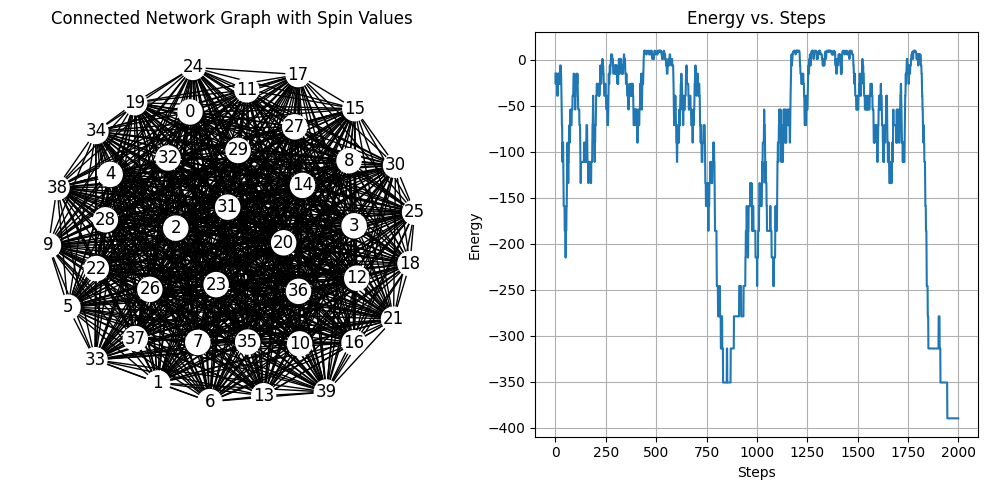

```python
import numpy as np
import matplotlib.pyplot as plt
import networkx as nx

def initialize_spin_graph(graph):
    for node in graph.nodes():
        graph.nodes[node]['spin'] = np.random.choice([-1, 1])

def calculate_energy(graph):
    energy = 0
    for edge in graph.edges():
        i, j = edge
        energy += -graph.nodes[i]['spin'] * graph.nodes[j]['spin']
    return energy / 2

def metropolis(graph, temperature):
    node = np.random.choice(list(graph.nodes()))
    spin = graph.nodes[node]['spin']
    neighbors = list(graph.neighbors(node))
    neighbor = np.random.choice(neighbors)
    energy_diff = 2 * spin * graph.nodes[neighbor]['spin']
    if energy_diff < 0 or np.random.rand() < np.exp(-energy_diff / temperature):
        graph.nodes[node]['spin'] = -spin

def simulate_ising_model(graph, temperature, steps):
    energies = []
    spin_configs = []
    for _ in range(steps):
        metropolis(graph, temperature)
        energy = calculate_energy(graph)
        energies.append(energy)

        # Store the current spin configuration
        current_spin_config = [graph.nodes[node]['spin'] for node in graph.nodes()]
        spin_configs.append(current_spin_config)

    return spin_configs, energies


def linear_graph(m):
    ''' Constructs and returns a linear graph. '''

    edges = []
    for i in range(m-1):
        edges.append((i,i+1))

    graph = nx.Graph(edges)

    return graph

def beaded_graph(beads: int, bead_size: int):
    ''' Constructs a graph with fully connected beads joined by bridges.
        Users can specify the number and size of beads. '''

    edges = []
    counter = 0
    for bead in range(beads):

        # Add an edge for each node pair in the bead, skipping self-connections
        for bead_node_source in range(bead_size):
            for bead_node_target in range(bead_size):
                if bead_node_source != bead_node_target:
                    edges.append((counter + bead_node_source, counter + bead_node_target))

        if counter > 0:
            # Add prior connection at lowest node
            edges.append((counter - 1, counter))

        # Add a bridge node after the bead
        edges.append((counter + bead_size - 1, counter + bead_size))

        # Increment the counter as needed
        counter = counter + bead_size + 1

    graph = nx.Graph(edges)

    return graph

def connected_graph(m):
    ''' Constructs and returns a fully connected graph. '''

    edges = []
    # Add an edge for each node pair in the bead, skipping self-connections
    for node_source in range(m):
        for node_target in range(m):
            if node_source != node_target:
                edges.append((node_source, node_target))

    graph = nx.Graph(edges)

    return graph


# Parameters
temperature = 0.4
steps = 2000

# Create a graph
m = 40
graph = connected_graph(m)

# Initialize spins
initialize_spin_graph(graph)

# Simulation
spin_configs, energies = simulate_ising_model(graph, temperature, steps)

# Plotting
plt.figure(figsize=(10, 5))

# Plot the network graph
plt.subplot(1, 2, 1)
pos = nx.spring_layout(graph)
nx.draw(graph, pos, with_labels=True, node_color=[graph.nodes[node]['spin'] for node in graph.nodes()], cmap=plt.cm.binary)
plt.title('Connected Network Graph with Spin Values')

# Plot the energy evolution
plt.subplot(1, 2, 2)
plt.plot(energies)
plt.title('Energy vs. Steps')
plt.xlabel('Steps')
plt.ylabel('Energy')
plt.grid(True)

plt.tight_layout()
plt.show()
```

```python
# Compute the diffusion map
diffusion_coords = diffusion_map(np.array(spin_configs))

# Example target distribution (e.g., based on a potential energy function)
beta = 8.0
target_distribution = np.exp(-beta * np.sum(diffusion_coords**2, axis=1))  # Simple quadratic potential

# Perform diffusion map
eval, evec = TMDmap(diffusion_coords, target_distribution, epsilon=1.0, beta=beta, n_components=10)
```

## Full map

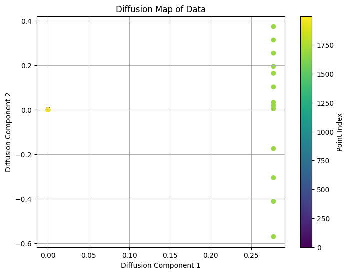

```
Top 3 Eigenvalues: [-1966215.3881959 -1966215.3908456 -1966215.3908456]
Corresponding Eigenvectors (first 3 rows):
 [[ 2.85754610e-08  3.03981568e-15 -8.18252832e-16]
 [ 2.85754609e-08  3.10066156e-15 -9.25824917e-16]
 [ 2.85754609e-08  3.11816255e-15 -3.80380240e-16]]
```

```python
# Plot the first two diffusion map components
plt.figure(figsize=(8, 6))
plt.scatter(evec[:, 0], evec[:, 1], c=np.arange(steps), cmap='viridis')
plt.colorbar(label='Point Index')
plt.title('Diffusion Map of Data')
plt.xlabel('Diffusion Component 1')
plt.ylabel('Diffusion Component 2')
plt.grid(True)
plt.show()

# Print the top 3 eigenvalues and their corresponding eigenvectors
print("Top 3 Eigenvalues:", eval[:3])
print("Corresponding Eigenvectors (first 3 rows):\n", evec[:3, :3])
```

## Initial states

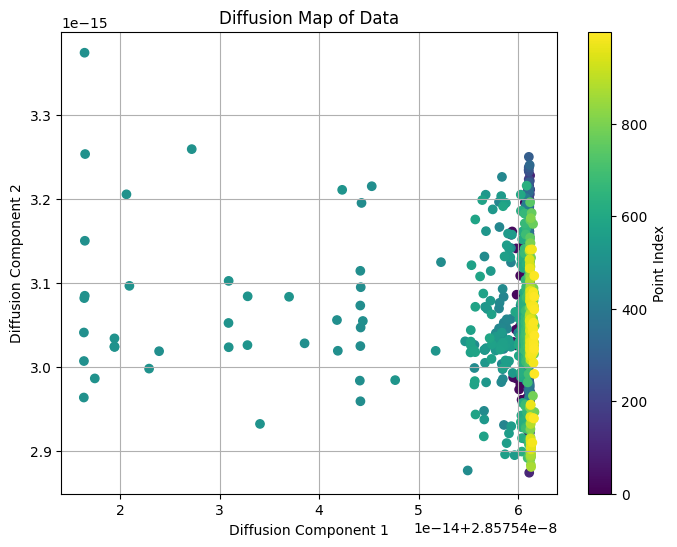

```
Top 3 Eigenvalues: [-1966215.3881959 -1966215.3908456 -1966215.3908456]
Corresponding Eigenvectors (first 3 rows):
 [[ 2.85754610e-08  3.03981568e-15 -8.18252832e-16]
 [ 2.85754609e-08  3.10066156e-15 -9.25824917e-16]
 [ 2.85754609e-08  3.11816255e-15 -3.80380240e-16]]
```

```python
# Plot the first two diffusion map components
plt.figure(figsize=(8, 6))
plt.scatter(evec[:1000, 0], evec[:1000, 1], c=np.arange(1000), cmap='viridis')
plt.colorbar(label='Point Index')
plt.title('Diffusion Map of Data')
plt.xlabel('Diffusion Component 1')
plt.ylabel('Diffusion Component 2')
plt.grid(True)
plt.show()

# Print the top 3 eigenvalues and their corresponding eigenvectors
print("Top 3 Eigenvalues:", eval[:3])
print("Corresponding Eigenvectors (first 3 rows):\n", evec[:3, :3])
```

# Beaded graph

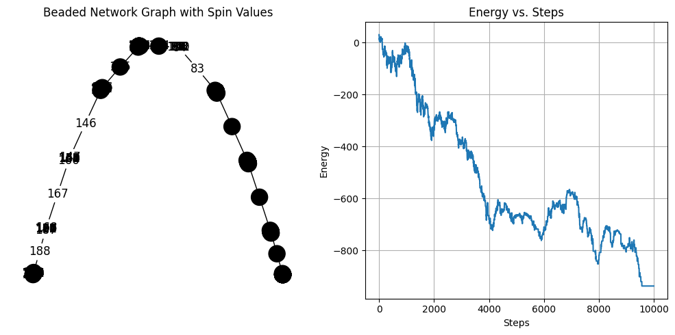

```python
# Parameters
temperature = 0.01
steps = 10000

# Create a graph
beads = 10
bead_size = 20
graph = beaded_graph(beads, bead_size)

# Initialize spins
initialize_spin_graph(graph)

# Simulation
spin_configs, energies = simulate_ising_model(graph, temperature, steps)

# Plotting
plt.figure(figsize=(10, 5))

# Plot the network graph
plt.subplot(1, 2, 1)
pos = nx.spectral_layout(graph)
nx.draw(graph, pos, with_labels=True, node_color=[graph.nodes[node]['spin'] for node in graph.nodes()], cmap=plt.cm.binary)
plt.title('Beaded Network Graph with Spin Values')

# Plot the energy evolution
plt.subplot(1, 2, 2)
plt.plot(energies)
plt.title('Energy vs. Steps')
plt.xlabel('Steps')
plt.ylabel('Energy')
plt.grid(True)

plt.tight_layout()
plt.show()
```

```python
# Compute the diffusion map
diffusion_coords = diffusion_map(np.array(spin_configs))

# Example target distribution (e.g., based on a potential energy function)
beta = 8.0
target_distribution = np.exp(-beta * np.sum(diffusion_coords**2, axis=1))  # Simple quadratic potential

# Perform diffusion map
eval, evec = TMDmap(diffusion_coords, target_distribution, epsilon=1.0, beta=beta, n_components=10)
```

## Full map

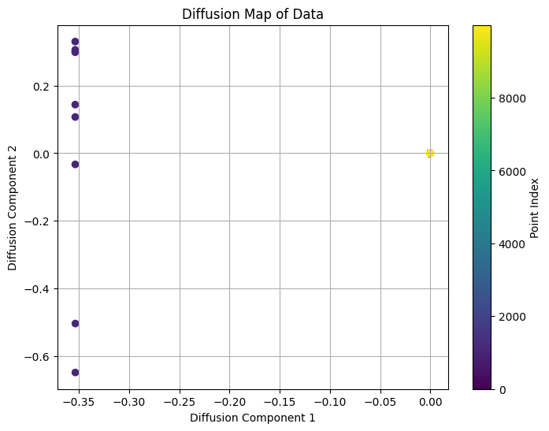

```
Top 3 Eigenvalues: [-49144007.54686031 -49144007.54716776 -49144007.54716781]
Corresponding Eigenvectors (first 3 rows):
 [[-1.29664115e-10 -2.54920384e-14 -7.56549168e-15]
 [-1.29664129e-10 -2.54455392e-14 -7.56943393e-15]
 [-1.29664100e-10 -2.53730417e-14 -7.74331758e-15]]
```

```python
# Plot the first two diffusion map components
plt.figure(figsize=(8, 6))
plt.scatter(evec[:, 0], evec[:, 1], c=np.arange(steps), cmap='viridis')
plt.colorbar(label='Point Index')
plt.title('Diffusion Map of Data')
plt.xlabel('Diffusion Component 1')
plt.ylabel('Diffusion Component 2')
plt.grid(True)
plt.show()

# Print the top 3 eigenvalues and their corresponding eigenvectors
print("Top 3 Eigenvalues:", eval[:3])
print("Corresponding Eigenvectors (first 3 rows):\n", evec[:3, :3])
```

## Initial states

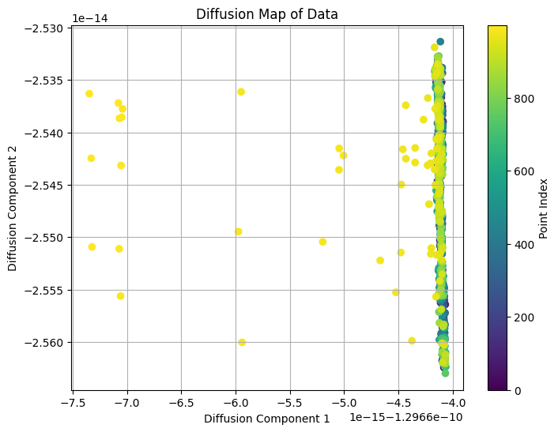

```
Top 3 Eigenvalues: [-49144007.54686031 -49144007.54716776 -49144007.54716781]
Corresponding Eigenvectors (first 3 rows):
 [[-1.29664115e-10 -2.54920384e-14 -7.56549168e-15]
 [-1.29664129e-10 -2.54455392e-14 -7.56943393e-15]
 [-1.29664100e-10 -2.53730417e-14 -7.74331758e-15]]
```

```python
# Plot the first two diffusion map components
plt.figure(figsize=(8, 6))
plt.scatter(evec[:1000, 0], evec[:1000, 1], c=np.arange(1000), cmap='viridis')
plt.colorbar(label='Point Index')
plt.title('Diffusion Map of Data')
plt.xlabel('Diffusion Component 1')
plt.ylabel('Diffusion Component 2')
plt.grid(True)
plt.show()

# Print the top 3 eigenvalues and their corresponding eigenvectors
print("Top 3 Eigenvalues:", eval[:3])
print("Corresponding Eigenvectors (first 3 rows):\n", evec[:3, :3])
```

## Final states

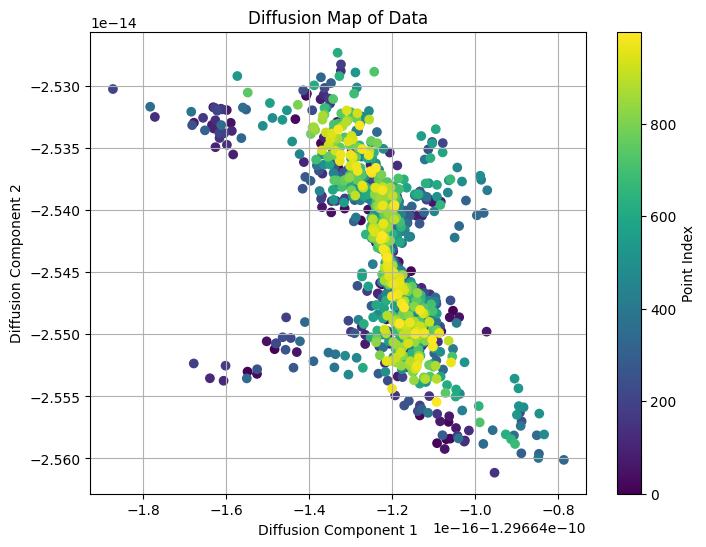

```
Top 3 Eigenvalues: [-49144007.54686031 -49144007.54716776 -49144007.54716781]
Corresponding Eigenvectors (first 3 rows):
 [[-1.29664115e-10 -2.54920384e-14 -7.56549168e-15]
 [-1.29664129e-10 -2.54455392e-14 -7.56943393e-15]
 [-1.29664100e-10 -2.53730417e-14 -7.74331758e-15]]
```

```python
# Plot the first two diffusion map components
plt.figure(figsize=(8, 6))
plt.scatter(evec[-1000:, 0], evec[-1000:, 1], c=np.arange(1000), cmap='viridis')
plt.colorbar(label='Point Index')
plt.title('Diffusion Map of Data')
plt.xlabel('Diffusion Component 1')
plt.ylabel('Diffusion Component 2')
plt.grid(True)
plt.show()

# Print the top 3 eigenvalues and their corresponding eigenvectors
print("Top 3 Eigenvalues:", eval[:3])
print("Corresponding Eigenvectors (first 3 rows):\n", evec[:3, :3])
```

# Spiral graph

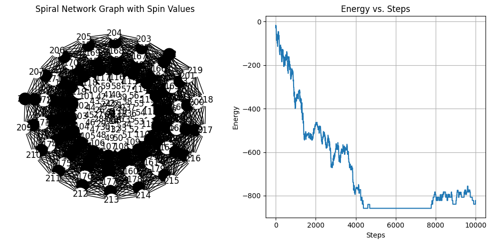

```python
import numpy as np
import matplotlib.pyplot as plt
import networkx as nx

def spiral_graph(center_size, node_size, spokes, layers):
    ''' Constructs a graph structure modeling a spiral galaxy, with a central node cluster and
        spiraling arms which radiate outwards.

        Args:
            center_size: number of nodes in the central cluster
            node_size: number of nodes in each cluster, assumed to be constant throughout network
            spokes: number of spiral arms
            layers: number of layers for each arm
    '''
    edges = []

    # Add an edge for each node pair in the bead, skipping self-connections
    for layer in range(layers):

        # Construct inner cluster
        if layer==0:
            for node_source in range(center_size):
                for node_target in range(center_size):
                    if node_source != node_target:
                        edges.append((node_source, node_target))

        # For each cluster in first layer, add connection to inner cluster and then construct cluster
        elif layer == 1:
            lower_count = center_size
            for spoke in range(spokes):

                # Add edge to center cluster
                edges.append((center_size - 1, lower_count + spoke * node_size))

                # Add connected component
                for node_source in range(lower_count + spoke * node_size, lower_count + spoke * node_size + node_size):
                    for node_target in range(lower_count + spoke * node_size, lower_count + spoke * node_size + node_size):
                        if node_source != node_target:
                            edges.append((node_source, node_target))

        else:
            lower_count = center_size + layer * spokes * node_size

            for spoke in range(spokes):
                # Add edge to lower layer
                edges.append((center_size + (layer - 1) * spokes * node_size + spoke * node_size - 1,
                                lower_count + spoke * node_size))

                # Add connected component
                for node_source in range(lower_count + spoke * node_size, lower_count + (spoke + 1) * node_size):
                    for node_target in range(lower_count + spoke * node_size, lower_count + (spoke + 1) * node_size):
                        if node_source != node_target:
                            edges.append((node_source, node_target))

    graph = nx.Graph(edges)

    return graph


# Parameters
temperature = 0.1
steps = 10000

# Create a graph
layers = 5
node_size = 20
spokes = 2
center_size = 20
graph = spiral_graph(center_size, node_size, spokes, layers)

# Initialize spins
initialize_spin_graph(graph)

# Simulation
spin_configs, energies = simulate_ising_model(graph, temperature, steps)

# Plotting
plt.figure(figsize=(10, 5))

# Plot the network graph
plt.subplot(1, 2, 1)
pos = nx.spiral_layout(graph)
nx.draw(graph, pos, with_labels=True, node_color=[graph.nodes[node]['spin'] for node in graph.nodes()], cmap=plt.cm.binary)
plt.title('Spiral Network Graph with Spin Values')

# Plot the energy evolution
plt.subplot(1, 2, 2)
plt.plot(energies)
plt.title('Energy vs. Steps')
plt.xlabel('Steps')
plt.ylabel('Energy')
plt.grid(True)

plt.tight_layout()
plt.show()
```

```python
# Compute the diffusion map
diffusion_coords = diffusion_map(np.array(spin_configs))

# Example target distribution (e.g., based on a potential energy function)
beta = 8.0
target_distribution = np.exp(-beta * np.sum(diffusion_coords**2, axis=1))  # Simple quadratic potential

# Perform diffusion map
eval, evec = TMDmap(diffusion_coords, target_distribution, epsilon=1.0, beta=beta, n_components=10)
```

## Full map

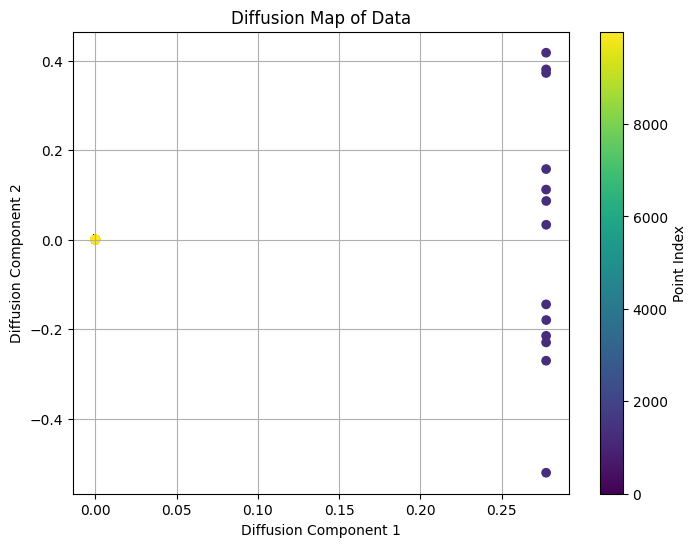

```
Top 3 Eigenvalues: [-49640904.91009248 -49640904.91068005 -49640904.91068009]
Corresponding Eigenvectors (first 3 rows):
 [[5.13933774e-10 8.59281865e-16 7.08055493e-15]
 [5.13933744e-10 9.60982323e-16 6.99709753e-15]
 [5.13933719e-10 9.13853644e-16 7.09207655e-15]]
```

```python
# Plot the first two diffusion map components
plt.figure(figsize=(8, 6))
plt.scatter(evec[:, 0], evec[:, 1], c=np.arange(steps), cmap='viridis')
plt.colorbar(label='Point Index')
plt.title('Diffusion Map of Data')
plt.xlabel('Diffusion Component 1')
plt.ylabel('Diffusion Component 2')
plt.grid(True)
plt.show()

# Print the top 3 eigenvalues and their corresponding eigenvectors
print("Top 3 Eigenvalues:", eval[:3])
print("Corresponding Eigenvectors (first 3 rows):\n", evec[:3, :3])
```

## Initial states

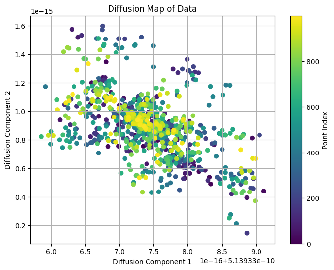

```
Top 3 Eigenvalues: [-49640904.91009248 -49640904.91068005 -49640904.91068009]
Corresponding Eigenvectors (first 3 rows):
 [[5.13933774e-10 8.59281865e-16 7.08055493e-15]
 [5.13933744e-10 9.60982323e-16 6.99709753e-15]
 [5.13933719e-10 9.13853644e-16 7.09207655e-15]]
```

```python
# Plot the first two diffusion map components
plt.figure(figsize=(8, 6))
plt.scatter(evec[:1000, 0], evec[:1000, 1], c=np.arange(1000), cmap='viridis')
plt.colorbar(label='Point Index')
plt.title('Diffusion Map of Data')
plt.xlabel('Diffusion Component 1')
plt.ylabel('Diffusion Component 2')
plt.grid(True)
plt.show()

# Print the top 3 eigenvalues and their corresponding eigenvectors
print("Top 3 Eigenvalues:", eval[:3])
print("Corresponding Eigenvectors (first 3 rows):\n", evec[:3, :3])
```

## Final states

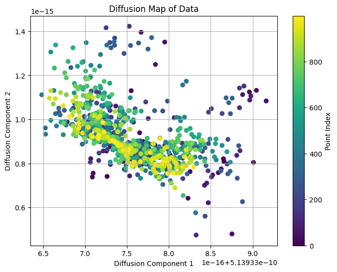

```
Top 3 Eigenvalues: [-49640904.91009248 -49640904.91068005 -49640904.91068009]
Corresponding Eigenvectors (first 3 rows):
 [[5.13933774e-10 8.59281865e-16 7.08055493e-15]
 [5.13933744e-10 9.60982323e-16 6.99709753e-15]
 [5.13933719e-10 9.13853644e-16 7.09207655e-15]]
```

```python
# Plot the first two diffusion map components
plt.figure(figsize=(8, 6))
plt.scatter(evec[-1000:, 0], evec[-1000:, 1], c=np.arange(1000), cmap='viridis')
plt.colorbar(label='Point Index')
plt.title('Diffusion Map of Data')
plt.xlabel('Diffusion Component 1')
plt.ylabel('Diffusion Component 2')
plt.grid(True)
plt.show()

# Print the top 3 eigenvalues and their corresponding eigenvectors
print("Top 3 Eigenvalues:", eval[:3])
print("Corresponding Eigenvectors (first 3 rows):\n", evec[:3, :3])
```

## Intermediate steps

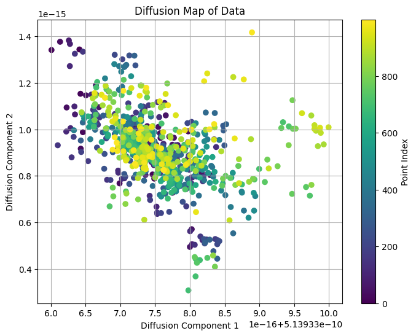

```
Top 3 Eigenvalues: [-49640904.91009248 -49640904.91068005 -49640904.91068009]
Corresponding Eigenvectors (first 3 rows):
 [[5.13933774e-10 8.59281865e-16 7.08055493e-15]
 [5.13933744e-10 9.60982323e-16 6.99709753e-15]
 [5.13933719e-10 9.13853644e-16 7.09207655e-15]]
```

```python
# Plot the first two diffusion map components
plt.figure(figsize=(8, 6))
plt.scatter(evec[7500:8500, 0], evec[7500:8500, 1], c=np.arange(1000), cmap='viridis')
plt.colorbar(label='Point Index')
plt.title('Diffusion Map of Data')
plt.xlabel('Diffusion Component 1')
plt.ylabel('Diffusion Component 2')
plt.grid(True)
plt.show()

# Print the top 3 eigenvalues and their corresponding eigenvectors
print("Top 3 Eigenvalues:", eval[:3])
print("Corresponding Eigenvectors (first 3 rows):\n", evec[:3, :3])
```